# La MotoGP

Anna Scussolin

La MotoGP è cominciata nel 2002, sostituendo la precendente classe maggiore, la 500. Per lo studio in analisi si è deciso di escludere le prime tre edizioni della nuova classe regina poichè al tempo erano presenti sia moto con motori a due tempi sia con motori a quattro tempi, questa differenza comportava performance diverse.  
Dall’anno preso in esame (2005) non erano più presenti tali differenze poichè tutte le case costruttrici hanno adottato il motore a quattro tempi.  
Inoltre nello studio non sono stati presi in considerazione i cambi di cilindrata e di fornitura di pneumatici che nel corso delle varie stagioni sono stati richiesti dal Regolamento del Motomondiale.

L’analisi cercherà di rispondere alle seguenti domande:

1. Quale legame esiste tra una buona posizione in qualifica e il risultato in gara?
2. Come sono legate le pole position con i giri in prima posizione e i giri veloci?
3. Attraverso quali parametri si riesce a determinare il/i pilota/i migliore/i? Chi sono i piloti più forti? Analisi dei piloti più forti (c.d. “big”).
4. Diventare campione del mondo della MotoGP vuol dire essere realmente il pilota più forte della stagione?
5. Esiste una relazione tra la nazionalità del vincitore e l’ubicazione del circuito? C’è una relazione tra il circuito e la marca della moto vincitrice?

## 1.1 DataBase

In tale analisi sono stati utilizzati 3 dataset (denominati piloti,giri e vincitori2.0), che mettono in luce i vari aspetti dell’analisi.

### 1.1.1 Dataset piloti

Nel dataset piloti le variabili sono le seguenti:

- *Posizione* : indica la posizione del pilota nel campionato del relativo anno.
- *Rider* : cognome del pilota. [**N.b.** Sono stati posti dei particolari caratteri per poter riconoscere piloti che hanno omonimia nel cognome].
- *Nome* : nome del pilota.
- *Punti* : punti ottenuti dal pilota nel corso di quell’edizione del mondiale.
- *Anno* : anno di rilevazione dei dati. I dati si riferiscono alle edizioni della MotoGP dal 2005 al 2017 -dati di ogni singolo anno-.
- Le successive colonne rappresentano il risultato in qualifica (*qual1*, *qual2*, …, *qual18*) e in gara(*GARA1*, *GARA2*,…,*GARA18*) per ogni singolo circuito.  
  Tuttavia si precisa che nelle varie edizioni del Motomondiale, l’ordine, il numero e i circuiti sono cambiati, pertanto non si può confrontare direttamente dal database i risultati per la medesima gara nei vari anni. Il confronto si può fare ricorrendo al sito da cui sono stati presi i dati [link](http://www.motogp.com/it/Results+Statistics).

### 1.1.2 Dataset giri

Il dataset giri descrive delle informazioni di carattere quantitativo riguardanti:

- *Posizione*: indica la posizione del pilota nel mondiale nell’anno considerato.
- *X_1* : nome del pilota.
- *Rider* : cognome del pilota. [**N.b.** Sono stati posti dei particolari caratteri per poter riconoscere piloti che hanno omonimia nel cognome].
- *Punti* : punti ottenuti dal pilota nel corso di quell’edizione del mondiale.
- *Anno* : anno di rilevazione dei dati. I dati si riferiscono alle edizioni della MotoGP dal 2005 al 2017 -dati di ogni singolo anno-.
- *N. Vittorie*: rappresenta il numero totale di vittorie conseguite dal pilota nel corso della stagione in esame.
- *2 posti*: rappresenta il numero totale di secondi posti conseguiti dal pilota nel corso della stagione in esame.
- *3 posti*: rappresenta il numero totale di terzi posti conseguiti dal pilota nel corso della stagione in esame.
- *Giri veloci*: rappresenta il numero di giri veloci conseguiti dal pilota nel corso della stagione in esame. [Durante ogni singola gara viene assegnato il *giro veloce* ad un solo pilota che fa segnare il miglior tempo]
- *Pole*: rappresenta il numero totale di pole position conseguite dal pilota nel corso della stagione in esame. [*pole position* rappresenta il miglior tempo effettuato nelle qualifiche]
- *Giri in prima posizione*: rappresenta il numero totale di giri in prima posizione effettuati dal pilota nel corso della stagione in esame.

### 1.1.3 Dataset Vincitori2.0

Il dataset Vincitori2.0 contiene alcune informazioni riguardanti i vincitori dei Granpremi nelle diverse stagioni.  
Per semplicità si è deciso di rinominare le nazionalità, il codice del circuito e la casa costruttrice con un numero evidenziati con un file apposito. Nomenclatura <- read.csv(“Nomenclatura.txt”)

- *Stagione* : anno del campionato cui si riferiscono i dati.
- *Nome Circuito* : nome per esteso del circuito.
- *Sigla circuito* : sigla di riconoscimento del circuito (modificata con un numero, vedi Nomenclatura).
- *Paese* : Paese in cui si trova il circuito (modificato con un numero, vedi Nomenclatura).
- *Pilota* : cognome del pilota.[**N.b.** Sono stati posti dei particolari caratteri per poter riconoscere piloti che hanno omonimia nel cognome]
- *Nazionalità* : nazionalità del pilota (modificata con un numero, vedi Nomenclatura).
- *Costruttore* : nome della casa costruttrice con cui il pilota vince la gara (modificato con un numero, vedi Nomenclatura).

## 1.2 Library

Si riportano tutti i pacchetti che verranno utilizzati nel corso dell’analisi:

```r
library(dplyr)
library(tidyverse)
library(ggrepel)
library(readxl)
library(corrplot)
library(knitr)
```

## 1.3 Avvertenze

- Nel corso dello studio non tutti i piloti sono stati presi in considerazione dalla totalità delle analisi.
- I diversi Granpremi nel corso della singola stagione sono identificati con un numero progressivo.

## 1.4 Le analisi

# 1. Quale legame esiste tra una buona posizione in qualifica e il risultato in gara?

Per poter rispondere a questa domanda va caricato il dataset piloti.

```r
piloti <- read_excel("Dataset_piloti.xlsx")
```

Successivamente vanno sostituite le sigle presenti (NC=Not classified NL=Not finished first lap NP=Not started race re-start N2=Not finished first lap race re-start EX=Excluded NS=Not Started DS=Disqualified) con caselle con valore 0. Si precisa che chi, per qualsiasi motivo non termina la gara, ottenendo 0 punti in campionato, è come se non avesse partecipato alla gara.

```r
piloti[piloti=="NC"]<-0
piloti[piloti=="NL"]<-0
piloti[piloti=="EX"]<-0
piloti[piloti=="NS"]<-0
piloti[piloti=="NP"]<-0
piloti[piloti=="DS"]<-0
piloti[piloti=="N2"]<-0
piloti[is.na(piloti)]<-0
```

```r
#Verifica di chiave primaria
piloti%>%
  count(Rider,Anno)%>%
  filter(n>1)
```

```
## # A tibble: 0 x 3
## # ... with 3 variables: Rider <chr>, Anno <dbl>, n <int>
```

Notiamo che questa tabella non è in formato tidy poichè abbiamo colonne che non sono variabili.  
Con la funzione “gather” si ottiene una tabella stretta e molto lunga.  
Viene creata quindi una colonna che rappresenta la posizione della qualifica e una per il risultato della gara.

```r
piloti2=piloti
piloti2=piloti2%>%gather('qual1', 'qual2','qual3', 'qual4','qual5','qual6', 'qual7', 'qual8', 'qual9','qual10','qual11','qual12','qual13','qual14','qual15','qual16','qual17','qual18',key="circuito", value="Qualifica")
piloti2=piloti2[,-c(6:23)]
piloti2=piloti2[,-c(3:4)]

piloti3=piloti%>%gather('GARA1', 'GARA2','GARA3', 'GARA4','GARA5','GARA6', 'GARA7', 'GARA8', 'GARA9','GARA10','GARA11','GARA12','GARA13','GARA14','GARA15','GARA16','GARA17','GARA18',key="circuito", value="risultato")
piloti3=piloti3[,-c(6:23)]
piloti3=piloti3[,-c(3:4)]

prova=piloti2%>%mutate(Risultato=piloti3$risultato)
#trasformo le colonne dal tipo character in numeric
prova[, 5] <- sapply(prova[, 5], as.numeric)
prova[, 6] <- sapply(prova[, 6], as.numeric)
```

Vengono esclusi i piloti che non partecipano alla gara ovvero quelli che hanno il valore della qualifica pari a 0. Infatti, nel corso della stagione ci possono essere piloti che partecipano solo ad alcune gare (piloti wild car) o che sostituiscono un pilota infortunato: questi piloti vengono considerati solo per le gare a cui partecipano.

```
##
##  Pearson's product-moment correlation
##
## data:  senza$Qualifica and senza$Risultato
## t = 41.534, df = 4606, p-value < 2.2e-16
## alternative hypothesis: true correlation is not equal to 0
## 95 percent confidence interval:
##  0.5006642 0.5426873
## sample estimates:
##       cor
## 0.5219924
```

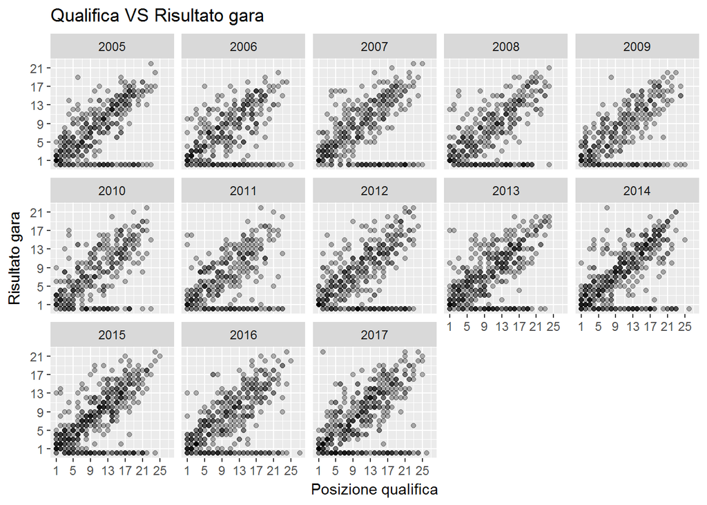

Dal risultato del coefficiente di correlazione (pari a 0.52) si evidenzia che c’è un legame importante, ma non fondamentale, tra la posizione della qualifica rispetto al risultato della gara. Si nota che ci sono piloti che ottengono migliori risultati nel giro di qualifica rispetto a quelli conseguiti in gara.

```r
prova_qualgara=prova%>%filter(prova$Anno==2017,
                                prova$Rider=="ROSSI"|prova$Rider=="IANNONE"|prova$Rider=="PEDROSA"|prova$Rider=="LORENZO"|prova$Rider=="MARQUEZ"|prova$Rider=="CRUTCHLOW" | prova$Rider=="ZARCO"| prova$Rider=="ESPARGARO"| prova$Rider=="VIÑALES")
prova_qualgara=prova_qualgara%>%filter(prova_qualgara$Qualifica !=0)
diff_qualgara1=mutate(prova_qualgara,diff_qualgara=(prova_qualgara$Qualifica-prova_qualgara$Risultato) )

#posizione media della qualifica anno 2017
aggregate(diff_qualgara1$Qualifica~diff_qualgara1$Rider, data=diff_qualgara1, FUN =mean)
```

```
##   diff_qualgara1$Rider        V1
## 1            CRUTCHLOW  8.111111
## 2            ESPARGARO 11.294118
## 3              IANNONE 11.611111
## 4              LORENZO  8.111111
## 5              MARQUEZ  2.666667
## 6              PEDROSA  5.888889
## 7                ROSSI  5.941176
## 8              VIÑALES  5.388889
## 9                ZARCO  7.000000
```

```r
#risultato medio anno 2017
aggregate(diff_qualgara1$Risultato~diff_qualgara1$Rider, data=diff_qualgara1, FUN =mean)
```

```
##   diff_qualgara1$Rider       V1
## 1            CRUTCHLOW 5.666667
## 2            ESPARGARO 4.882353
## 3              IANNONE 7.944444
## 4              LORENZO 6.500000
## 5              MARQUEZ 1.888889
## 6              PEDROSA 4.277778
## 7                ROSSI 4.000000
## 8              VIÑALES 4.277778
## 9                ZARCO 6.388889
```

```r
#differenza media tra qualifica e risultato anno 2017
aggregate(diff_qualgara1$diff_qualgara~ diff_qualgara1$Rider, data = diff_qualgara1, FUN=mean)
```

```
##   diff_qualgara1$Rider        V1
## 1            CRUTCHLOW 2.4444444
## 2            ESPARGARO 6.4117647
## 3              IANNONE 3.6666667
## 4              LORENZO 1.6111111
## 5              MARQUEZ 0.7777778
## 6              PEDROSA 1.6111111
## 7                ROSSI 1.9411765
## 8              VIÑALES 1.1111111
## 9                ZARCO 0.6111111
```

## 2.Come sono legate le pole position con i giri in prima posizione e i giri veloci?

Si pensa che il pilota che effettua la pole position sia quello che abbia maggior possibilità di vincere la gara.Attraverso l’analisi seguente viene rappresentata la correlazione che intercorre tra il numero di pole position, il numero di giri veloci e il numero di giri in prima posizione.

```r
#carichiamo il dataset giri
giri <- read_excel("Dataset_giri.xlsx")
giri[is.na(giri)]<-0

#Verifica della chiave primaria
giri%>%
  count(Rider,Anno)%>%
  filter(n>1)
```

```
## # A tibble: 0 x 3
## # ... with 3 variables: Rider <chr>, Anno <dbl>, n <int>
```

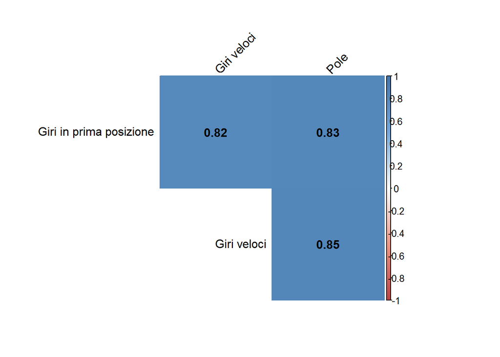

```r
#correlazione pole position, giri veloci e giri in prima posizione
s=giri[,9:11]
M<-cor(s)
col <- colorRampPalette(c("#BB4444", "#EE9988", "#FFFFFF", "#77AADD", "#4477AA"))
corrplot(M, method="color", col=col(200), type="upper", order="hclust", addCoef.col = "black", tl.col="black", tl.srt=45,diag=FALSE)
```

Si nota che i tre elementi presi in considerazione hanno un forte legame: normalmente chi effettua la pole il giorno della gara sarà uno dei favoriti per la vittoria. Ma conoscere questo legame tra i tre elementi ci permette di affermare che un pilota risulta più forte di un altro?

## 3. Attraverso quali parametri si riesce a determinare il/i pilota/i migliore/i? Chi sono i piloti più forti?

Nell’opinione comune si sostiene che il pilota più forte sia quello che riesce a vincere molto. Ma la vittoria è il parametro corretto per determinare la bravura di un corridore?

° La prima cosa da calcolare sono le frequenze di vittoria.

```r
n_vitto=aggregate(prova$Risultato==1 ~ prova$Rider, data = prova, sum)
n_gare=aggregate(prova$Qualifica != 0 ~ prova$Rider, data=prova, sum)

#dataset N. vittorie e N. gare disputate
df_pil_tot=data.frame(n_vitto,n_gare)
df_pil_tot=df_pil_tot[,-3]
names(df_pil_tot)[names(df_pil_tot) == "Risultato"] <- "N.Vittorie"
names(df_pil_tot)[names(df_pil_tot) == "Qualifica"] <- "N.gare disputate"
names(df_pil_tot)[names(df_pil_tot) == "prova.Rider"] <- "Rider"

#creo dataset con colonna delle frequenze (n. vittorie/n. gare disputate)
freq=mutate(df_pil_tot, freq=(df_pil_tot$N.Vittorie)/(df_pil_tot$`N.gare disputate`))
df_pil_tot2=df_pil_tot
df_pil_tot2=cbind(freq)
freq=round(df_pil_tot2$freq, digits = 2)
#dataset con frequenze arrotondate
df_pil_tot3=df_pil_tot
df_pil_tot3=cbind(df_pil_tot3,freq)
```

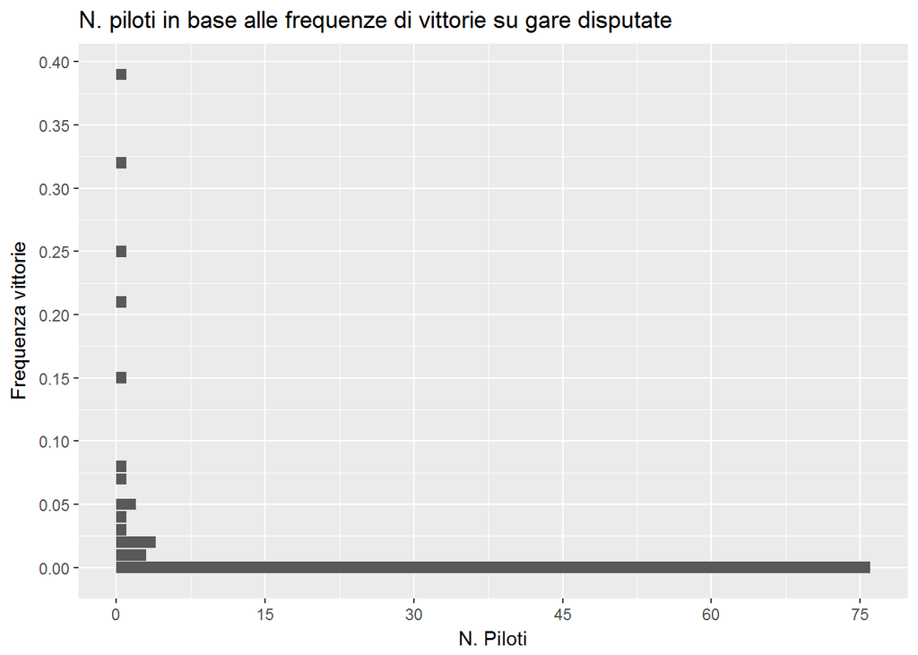

```r
#Rappresento la frequenza di vittorie
ggplot(df_pil_tot3)+
  geom_bar( aes(x=df_pil_tot3$freq),stat="count")+
  coord_flip()+
  scale_y_continuous("N. Piloti", breaks=seq(0,78,by=15))+
  scale_x_continuous("Frequenza vittorie", breaks=seq(0,0.4, by=0.05))+
  ggtitle("N. piloti in base alle frequenze di vittorie su gare disputate")+
  xlab("Frequenza vittoria")
```

Si noti che considerati i 94 piloti che hanno partecipato ad almeno una gara in MotoGP nelle ultime tredici edizioni, molti sono quelli che non hanno ottenuto una vittoria. Vengono esclusi dall’analisi coloro che non hanno vinto, e per tanto residuano 18 piloti che vengono rappresentati con nome e frequenza di vittoria.

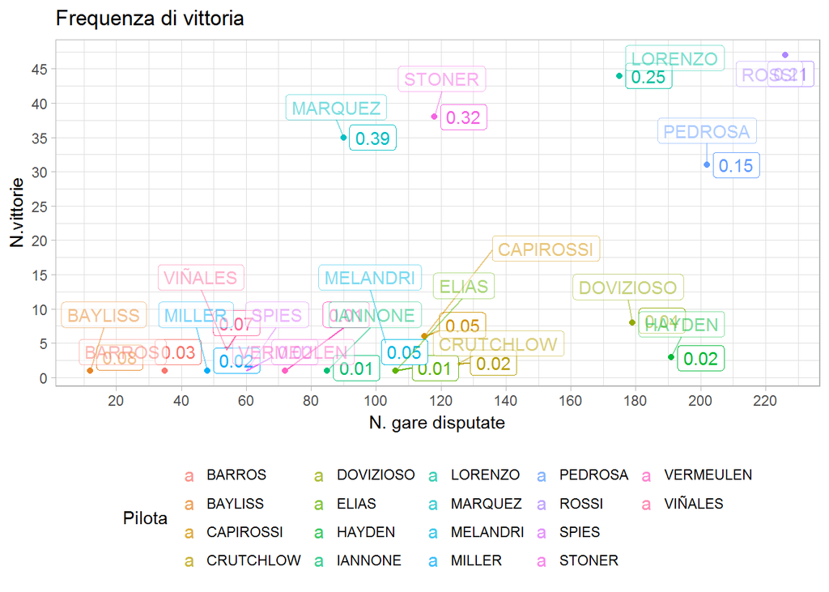

```r
freq2=df_pil_tot3%>%filter(df_pil_tot3$freq>0)
ggplot(freq2,aes(y=freq2$N.Vittorie, x=freq2$`N.gare disputate`, col=freq2$Rider))+
  geom_point()+
  scale_x_continuous("N. gare disputate", breaks=seq(0,270, by=20))+
  scale_y_continuous("N.vittorie", breaks=seq(0,50, by=5))+
  theme_light()+
  theme(legend.position = "bottom")+
  guides(colour = guide_legend(nrow = 4, override.aes = list(size = 4)))+
  labs(colour= "Pilota")+
  labs(title="Frequenza di vittoria")+
  ggrepel::geom_label_repel(aes(label=freq),freq2,nudge_x = 5, alpha = 1)+
  ggrepel::geom_label_repel(aes(label=Rider),freq2,nudge_y = 5, alpha = 0.5)
```

Dal grafico si può notare che ci sono piloti che hanno ottenuto molte vittorie (Rossi, Lorenzo, Pedrosa, Marquez, Stoner). Costoro si identificano come i piloti più forti?  
E’ bene sottolineare che le frequenze di vittoria non possono essere direttamente confrontate a causa del numero diverso di gare disputate dai diversi piloti. Quindi per decretare chi è/sono il/i pilota/i più forte/i non bisogna considerare unicamente il numero di vittorie ottenute.Allora,si analizza la posizione in campionato nei singoli anni (le stagioni sono tra di loro indipendenti).

°Da cosa dipende la posizione in campionato?

```r
mod1=lm(giri$Posizione~ giri$Punti+ giri$Anno+giri$`N. Vittorie`+giri$`2 posti`+
   giri$`3 posti`+giri$`Giri veloci`+giri$Pole+giri$`Giri in prima posizione`)
summary(mod1)
```

```
##
## Call:
## lm(formula = giri$Posizione ~ giri$Punti + giri$Anno + giri$`N. Vittorie` +
##     giri$`2 posti` + giri$`3 posti` + giri$`Giri veloci` + giri$Pole +
##     giri$`Giri in prima posizione`)
##
## Residuals:
##     Min      1Q  Median      3Q     Max
## -4.8896 -1.6977 -0.2557  1.3477  9.2492
##
## Coefficients:
##                                  Estimate Std. Error t value Pr(>|t|)
## (Intercept)                    -1.124e+02  6.934e+01  -1.621   0.1059
## giri$Punti                     -1.283e-01  3.186e-03 -40.252  < 2e-16 ***
## giri$Anno                       6.758e-02  3.447e-02   1.960   0.0508 .
## giri$`N. Vittorie`              1.977e+00  2.056e-01   9.617  < 2e-16 ***
## giri$`2 posti`                  1.046e+00  1.526e-01   6.854 3.47e-11 ***
## giri$`3 posti`                  9.657e-01  1.486e-01   6.497 2.97e-10 ***
## giri$`Giri veloci`             -1.510e-01  1.757e-01  -0.859   0.3907
## giri$Pole                      -1.863e-01  1.582e-01  -1.178   0.2397
## giri$`Giri in prima posizione`  1.191e-03  8.115e-03   0.147   0.8834
## ---
## Signif. codes:  0 '***' 0.001 '**' 0.01 '*' 0.05 '.' 0.1 ' ' 1
##
## Residual standard error: 2.443 on 335 degrees of freedom
## Multiple R-squared:  0.9128, Adjusted R-squared:  0.9108
## F-statistic: 438.6 on 8 and 335 DF,  p-value: < 2.2e-16
```

Dalle analisi si evince che la posizione in campionato è legata al punteggio, variabile a seconda dell’ordine di arrivo (file “Punteggi.txt”) e i podi che il pilota ottiene.  
Quindi il modello che meglio esprime il legame appena descritto è il modello 2:

```r
mod2=lm(giri$Posizione~ giri$Punti+giri$`N. Vittorie`+giri$`2 posti`+giri$`3 posti`)
summary(mod2)
```

```
##
## Call:
## lm(formula = giri$Posizione ~ giri$Punti + giri$`N. Vittorie` +
##     giri$`2 posti` + giri$`3 posti`)
##
## Residuals:
##     Min      1Q  Median      3Q     Max
## -4.7834 -1.7979 -0.3636  1.3746  9.4886
##
## Coefficients:
##                     Estimate Std. Error t value Pr(>|t|)
## (Intercept)        23.511400   0.218072 107.815  < 2e-16 ***
## giri$Punti         -0.128753   0.003194 -40.311  < 2e-16 ***
## giri$`N. Vittorie`  1.780902   0.109790  16.221  < 2e-16 ***
## giri$`2 posti`      0.975736   0.142529   6.846 3.58e-11 ***
## giri$`3 posti`      0.970470   0.148415   6.539 2.28e-10 ***
## ---
## Signif. codes:  0 '***' 0.001 '**' 0.01 '*' 0.05 '.' 0.1 ' ' 1
##
## Residual standard error: 2.455 on 339 degrees of freedom
## Multiple R-squared:  0.9109, Adjusted R-squared:  0.9099
## F-statistic: 866.9 on 4 and 339 DF,  p-value: < 2.2e-16
```

Quindi per decretare la bravura di un pilota ci si limita a considerare il numero di podi. Allora, va calcolata e rappresentata la frequenza di secondi e di terzi posti.

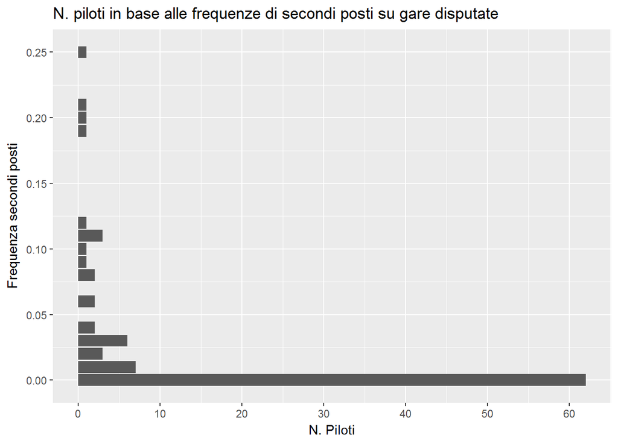

```r
n_secondi=aggregate(prova$Risultato==2 ~ prova$Rider, data = prova, sum)

df_pil_sec=data.frame(n_secondi,n_gare)
df_pil_sec=df_pil_sec[,-3]
names(df_pil_sec)[names(df_pil_sec) == "Risultato"] <- "N.secondi"
names(df_pil_sec)[names(df_pil_sec) == "Qualifica"] <- "N.gare disputate"
names(df_pil_sec)[names(df_pil_sec) == "prova.Rider"] <- "Rider"

#creo dataset con colonna delle frequenze (n.secondi/n. gare disputate)
freq2=mutate(df_pil_sec, freq2=(df_pil_sec$N.secondi)/(df_pil_sec$`N.gare disputate`))
df_pil_sec2=df_pil_sec
df_pil_sec2=cbind(freq2)
freq2=round(df_pil_sec2$freq2, digits = 2)
#dataset con frequenze arrotondate
df_pil_sec3=df_pil_sec
df_pil_sec3=cbind(df_pil_sec3,freq2)

ggplot(df_pil_sec3)+
  geom_bar( aes(x=df_pil_sec3$freq2),stat="count")+
  coord_flip()+
  ggtitle("N. piloti in base alle frequenze di secondi posti su gare disputate")+
  scale_x_continuous("Frequenza secondi posti", breaks=seq(0,1,by=0.05))+
  scale_y_continuous("N. Piloti", breaks=seq(0,70,by=10))
```

Ci sono 62 piloti su 94 che non hanno ottenuto mai un secondo posto.Per ottenere maggiore chiarezza, si escludono i piloti che non hanno ottenuto almeno un piazzamento sul secondo gradino del podio.

```r
sec2=df_pil_sec3%>%filter(df_pil_sec3$freq2>0)
arrange(sec2, freq2)
```

```
##         Rider N.secondi N.gare disputate freq2
## 1       BRADL         1               88  0.01
## 2   DE_PUNIET         1              141  0.01
## 3   ESPARGARO         1              129  0.01
## 4     HOPKINS         1               69  0.01
## 5     IANNONE         1               85  0.01
## 6      NAKANO         1               70  0.01
## 7       SMITH         1               86  0.01
## 8  DE_ANGELIS         1               62  0.02
## 9     EDWARDS         3              166  0.02
## 10      ELIAS         2              106  0.02
## 11  CRUTCHLOW         4              125  0.03
## 12     HAYDEN         6              191  0.03
## 13   PETRUCCI         3              101  0.03
## 14 ROBERTS_JR         1               38  0.03
```

[output cut: 18 more lines]

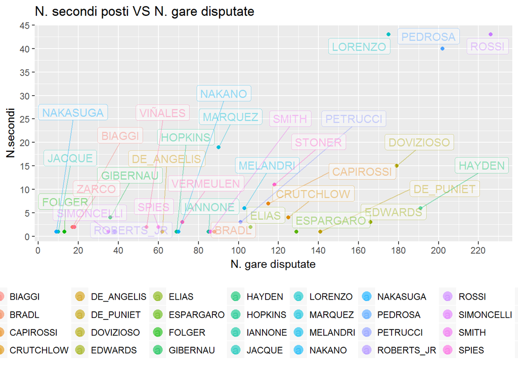

```r
ggplot(sec2,aes(y=sec2$N.secondi, x=sec2$`N.gare disputate`, col=sec2$Rider))+
  geom_point()+
  scale_x_continuous("N. gare disputate", breaks=seq(0,270, by=20))+
  scale_y_continuous("N.secondi", breaks=seq(0,50, by=5))+
  theme(legend.position = "bottom")+
  labs(colour= "Pilota")+
  labs(title="N. secondi posti VS N. gare disputate")+
  guides(colour = guide_legend(nrow = 4, override.aes = list(size = 4)))+
  ggrepel::geom_label_repel(aes(label=sec2$Rider),sec2,nudge_y = 2, alpha = 0.4)
```

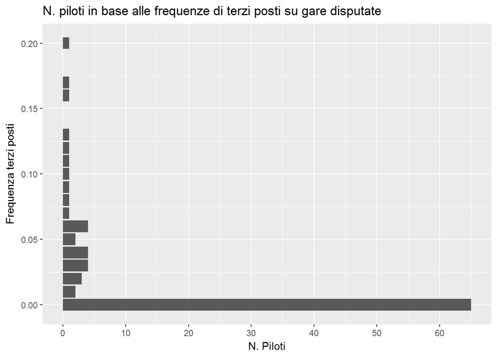

```r
n_terzi=aggregate(prova$Risultato==3 ~ prova$Rider, data = prova, sum)

df_pil_ter=data.frame(n_terzi,n_gare)
df_pil_ter=df_pil_ter[,-3]
names(df_pil_ter)[names(df_pil_ter) == "Risultato"] <- "N.terzi"
names(df_pil_ter)[names(df_pil_ter) == "Qualifica"] <- "N.gare disputate"
names(df_pil_ter)[names(df_pil_ter) == "prova.Rider"] <- "Rider"

freq3=mutate(df_pil_ter, freq3=(df_pil_ter$N.terzi)/(df_pil_ter$`N.gare disputate`))
df_pil_ter2=df_pil_ter
df_pil_ter2=cbind(freq3)
freq3=round(df_pil_ter2$freq3, digits = 2)
#dataset con frequenze arrotondate
df_pil_ter3=df_pil_ter
df_pil_ter3=cbind(df_pil_ter3,freq3)

ggplot(df_pil_ter3)+
  geom_bar( aes(x=df_pil_ter3$freq3),stat="count")+
  coord_flip()+
  ggtitle("N. piloti in base alle frequenze di terzi posti su gare disputate")+
  scale_x_continuous("Frequenza terzi posti", breaks=seq(0,1,by=0.05))+
  scale_y_continuous("N. Piloti", breaks=seq(0,70,by=10))
```

```r
ter2=df_pil_ter3%>%filter(df_pil_ter3$freq3>0)
arrange(ter2,freq3)
```

```
##         Rider N.terzi N.gare disputate freq3
## 1   DE_PUNIET       1              141  0.01
## 2       SMITH       1               86  0.01
## 3    BAUTISTA       3              140  0.02
## 4    PETRUCCI       2              101  0.02
## 5      TAMADA       1               49  0.02
## 6   CAPIROSSI       4              115  0.03
## 7       ELIAS       3              106  0.03
## 8     REDDING       2               72  0.03
## 9  SIMONCELLI       1               35  0.03
## 10      CHECA       2               54  0.04
## 11    EDWARDS       7              166  0.04
## 12    HOPKINS       3               69  0.04
## 13  VERMEULEN       3               72  0.04
## 14 ROBERTS_JR       2               38  0.05
## 15      SPIES       3               60  0.05
## 16     BARROS       2               35  0.06
## 17  CRUTCHLOW       7              125  0.06
## 18    IANNONE       5               85  0.06
## 19      ZARCO       1               18  0.06
## 20   MELANDRI       7              103  0.07
## 21     HAYDEN      15              191  0.08
## 22    VIÑALES       5               54  0.09
## 23    MARQUEZ       9               90  0.10
## 24  DOVIZIOSO      19              179  0.11
## 25     BIAGGI       2               17  0.12
## 26    LORENZO      23              175  0.13
## 27      ROSSI      36              226  0.16
## 28     STONER      20              118  0.17
## 29    PEDROSA      41              202  0.20
```